# ModelBuilding

Marieke

October 27, 2016

## Introduction

This code is built using the online github documentation of the caret package of Max Kuhn, [The caret Package](http://topepo.github.io/caret/index.html). Also the book [Applied predictive modeling by Max Kuhn and Kjel Johnson, 2013](http://www.amazon.com/Applied-Predictive-Modeling-Max-Kuhn/dp/1461468485/ref=pd_bxgy_b_img_z) was used. [Previous studies](http://www.sciencedirect.com/science/article/pii/S2211675315000482) also used the same the same approache.

## Loading library

```r
.libPaths("/usr/people/dirksen/R-20160725/x86_64-redhat-linux-gnu-library/3.3/")
library(data.table)
library(lubridate)
library(mgcv)
library(adehabitat)
library(automap)
library(caret)
library(doParallel)
library(kernlab)
library(reshape)
library(raster)
library(rgdal)
library(SDMTools)
library(plyr)
library(corrplot)
library(ggplot2)
pro=CRS("+init=epsg:28992")
save_dir<-"/nobackup/users/dirksen/radiation/Rdata/MLmodels/Linear_models/"
```

## Comparing the 2 products

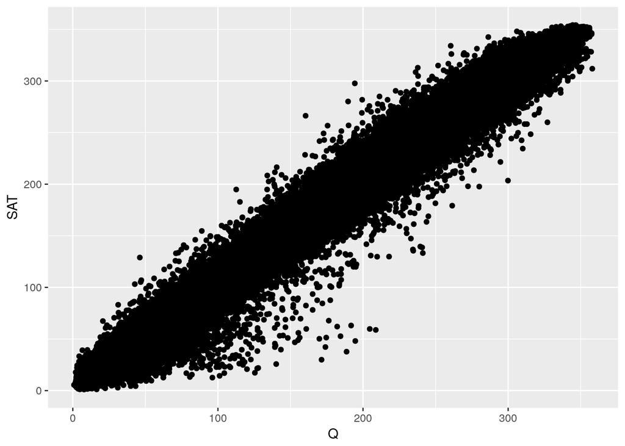

```r
obs.df <- fread("Rdata/sat_over_obs.csv")
names(obs.df) <- c("date","DS_CODE","Q","x","y","SAT","DIFF")
obs.df$date <- as.Date(obs.df$date)
obs.df$day <- yday(obs.df$date)
setkey(obs.df,date)

#Subquestion: do the "outliers" influence our fit?
obs.df.smalldiff<-obs.df[which(obs.df$DIFF<60 & obs.df$DIFF>-60)]
obs.df.smalldiff<-subset(obs.df.smalldiff,select=c("Q","SAT"))

obs.df<-subset(obs.df,select=c("Q","SAT"))
obs.df <- obs.df[complete.cases(obs.df),]


ggplot(data=obs.df,aes(x=Q,y=SAT))+
  geom_point()
```

## Training and test set

For an independent validation set the data is split into a train and test set.

```r
set.seed(999)
trainIndex<-createDataPartition(obs.df$Q,p=0.80,list=FALSE)
train<-obs.df[trainIndex,]
# setkey(train, day)
test<-obs.df[-trainIndex,]
# setkey(test, day)

train<-data.frame(train)
test<-data.frame(test)
```

```r
trainIndex.smalldiff<-createDataPartition(obs.df.smalldiff$Q,p=0.80,list=FALSE)
train.smalldiff<-obs.df.smalldiff[trainIndex.smalldiff,]
# setkey(train, day)
test.smalldiff<-obs.df.smalldiff[-trainIndex.smalldiff,]
# setkey(test, day)

train.smalldiff<-data.frame(train.smalldiff)
test.smalldiff<-data.frame(test.smalldiff)
```

## Online example

lets first try to reproduce the [online](https://www.r-bloggers.com/a-quick-introduction-to-machine-learning-in-r-with-caret/) example with our dataset.

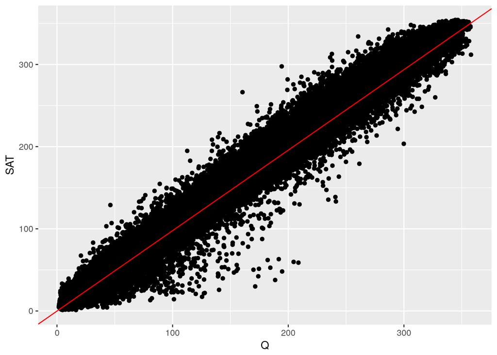

```r
model.obs_lm <- train(Q~SAT,
                      data=train,
                      method="lm")
# saveRDS(model.obs_lm,file=paste0(save_dir,"lm.rds"))

coef.icept <- coef(model.obs_lm$finalModel)[1]
coef.slope <- coef(model.obs_lm$finalModel)[2]
formula_lm<-as.character(as.expression(paste0("y = ",round(coef.slope,2),"x ",round(coef.icept,2))))
# dftext <- data.frame(x=50,y=300,eq=formula_lm)

ggplot(data=train,aes(x=Q,y=SAT)) +
  geom_point() +
  geom_abline(slope=coef.slope,intercept=coef.icept,color="red")
```

## What’s in the model?

The model we built used a linear regression. The model uses a bootstrapped method. Here the data is resampled, in this case 25 times, based on statistics.

```r
formula_lm
```

```
## [1] "y = 0.98x -0.13"
```

```r
model.obs_lm
```

```
## Linear Regression
##
## 108859 samples
##      1 predictor
##
## No pre-processing
## Resampling: Bootstrapped (25 reps)
## Summary of sample sizes: 108859, 108859, 108859, 108859, 108859, 108859, ...
## Resampling results:
##
##   RMSE      Rsquared
##   11.19154  0.9848713
##
## Tuning parameter 'intercept' was held constant at a value of TRUE
##
```

## Testing if everything is ok

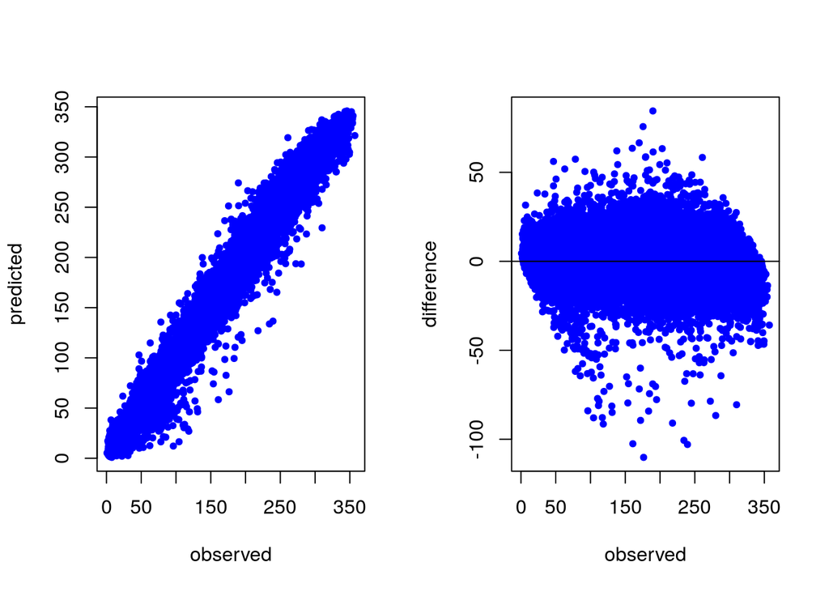

```r
lm.predict<-predict(model.obs_lm,newdata=test)
lm.diff<-lm.predict-test$Q

par(mfrow=c(1,2))
plot(test$Q,lm.predict,type="p",col="blue",pch=20,xlab="observed",ylab="predicted")
plot(test$Q,lm.diff,type="p",col="blue",pch=20,xlab="observed",ylab="difference")
abline(0,0)
mtext("lm", outer = TRUE, cex = 1.5)
```

## Data subset with differences between +60W/m2 and -60W/m2

Analysing the data subset without extreme outliers shows the fit is barely influenenced.

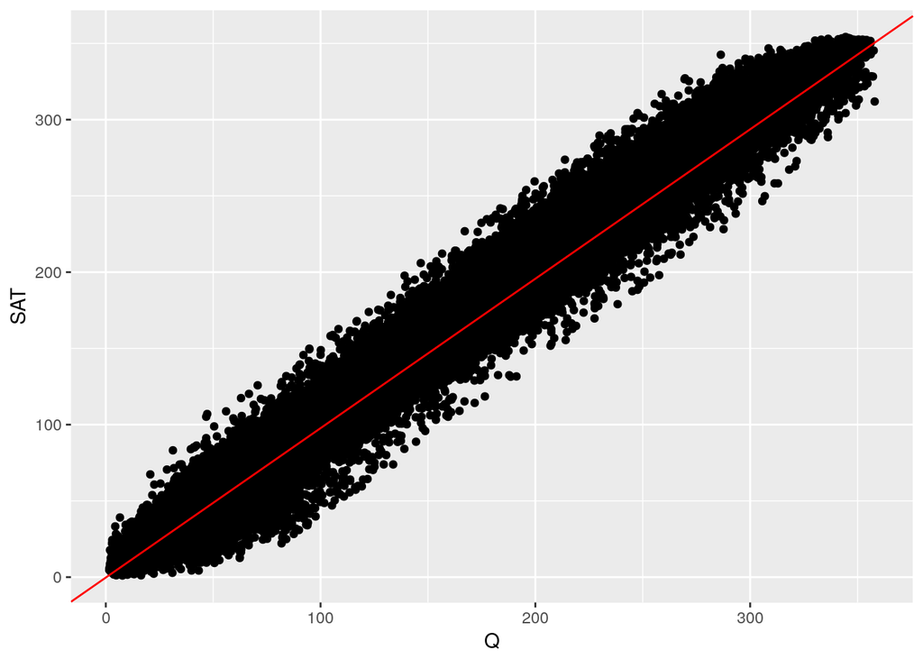

```r
model.obs_lm_2 <- train(Q~SAT,
                      data=train.smalldiff,
                      method="lm")
# saveRDS(model.obs_lm,file=paste0(save_dir,"lm.rds"))

coef.icept <- coef(model.obs_lm_2$finalModel)[1]
coef.slope <- coef(model.obs_lm_2$finalModel)[2]
formula_lm_2<-as.character(as.expression(paste0("y = ",round(coef.slope,2),"x ",round(coef.icept,2))))
# dftext <- data.frame(x=50,y=300,eq=formula_lm)

ggplot(data=train.smalldiff,aes(x=Q,y=SAT)) +
  geom_point() +
  geom_abline(slope=coef.slope,intercept=coef.icept,color="red")
```

```r
formula_lm_2
```

```
## [1] "y = 0.98x -0.28"
```

```r
model.obs_lm_2
```

```
## Linear Regression
##
## 108678 samples
##      1 predictor
##
## No pre-processing
## Resampling: Bootstrapped (25 reps)
## Summary of sample sizes: 108678, 108678, 108678, 108678, 108678, 108678, ...
## Resampling results:
##
##   RMSE      Rsquared
##   10.69227  0.986177
##
## Tuning parameter 'intercept' was held constant at a value of TRUE
##
```

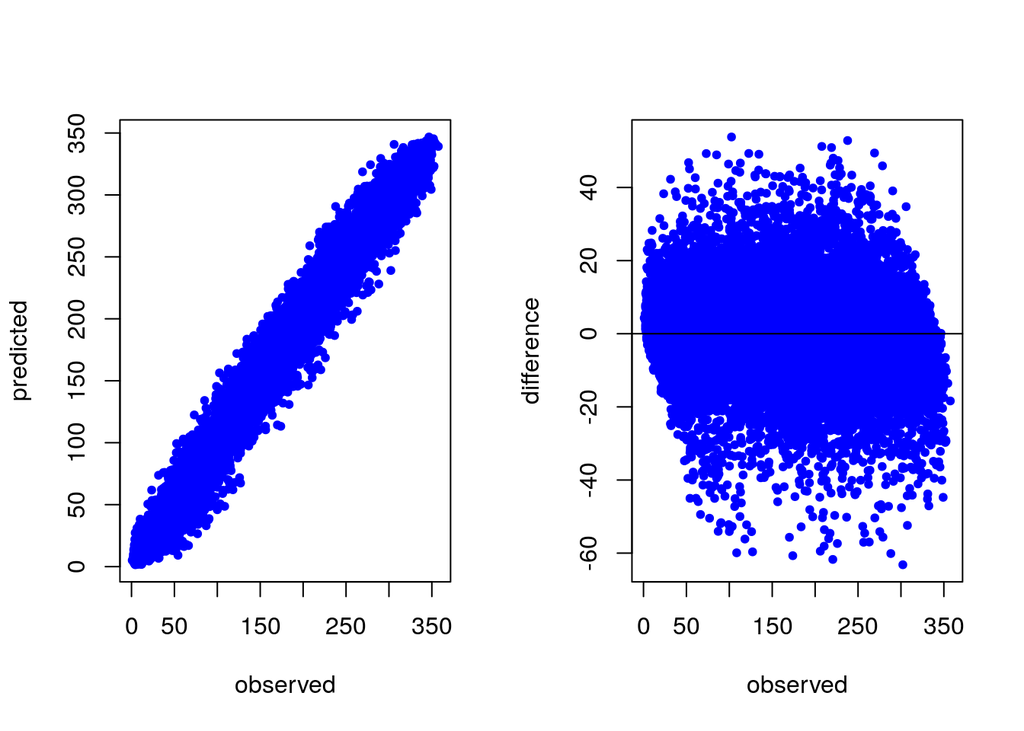

```r
lm.predict<-predict(model.obs_lm_2,newdata=test.smalldiff)
lm.diff<-lm.predict-test.smalldiff$Q

par(mfrow=c(1,2))
plot(test.smalldiff$Q,lm.predict,type="p",col="blue",pch=20,xlab="observed",ylab="predicted")
plot(test.smalldiff$Q,lm.diff,type="p",col="blue",pch=20,xlab="observed",ylab="difference")
abline(0,0)
mtext("lm", outer = TRUE, cex = 1.5)
```

## To be continued

This analysis resulted in a fit (y = 0.98x -0.13) which has a RMSE value of 11.19 and a 0.98. This already is a good result, but some things can be improved.

> With this analysis we ignored the time component. One posibility is to create multiple test and train sets within time with createTimeSlices. This would assume the previous days are correlated to the next, which is some sort of forecasting technique. But, as the differences between the datasets seem to differ with specific meteorological conditions (snow and cirrus) this would be, in my opinion a mistake. First, a more detailed analysis with the specific circomstances under which these differences occur would be in place. Next, with this knowlegde the models can be improved.

### Some notes

To include the previous day(s) see function ?lag. Or this [online post](http://stats.stackexchange.com/questions/108417/how-to-perform-proper-data-mining-on-time-series-data).